# Startup Acquisition Analysis: A Comprehensive Study of Crunchbase Data

## Data Quality Assessment

```r
# Missing values analysis
missing_summary <- companies_master %>%
  summarise_all(~sum(is.na(.))) %>%
  gather(variable, missing_count) %>%
  mutate(missing_percent = round(missing_count / nrow(companies_master) * 100, 1)) %>%
  filter(missing_count > 0) %>%
  arrange(desc(missing_count))

kable(missing_summary,
      caption = "Missing Values Summary",
      col.names = c("Variable", "Missing Count", "Missing %")) %>%
  kable_styling(bootstrap_options = "striped")
```

Missing Values Summary

| Variable | Missing Count | Missing % |
| --- | --- | --- |
| acquired_at | 35415 | 92.0 |
| state_code | 13765 | 35.8 |
| city | 3470 | 9.0 |
| country_code | 3031 | 7.9 |
| region | 3031 | 7.9 |
| homepage_url | 2139 | 5.6 |
| market | 1982 | 5.1 |
| category_list | 1977 | 5.1 |
| industry | 1977 | 5.1 |
| status | 918 | 2.4 |
| first_round | 8 | 0.0 |
| last_round | 8 | 0.0 |
| founded_month | 4 | 0.0 |
| founded_quarter | 4 | 0.0 |
| founded_year | 4 | 0.0 |

```r
# Key variable summary statistics - FIXED: Simplified approach
summary_data <- companies_master %>%
  dplyr::select(total_funding_usd, company_age, num_rounds, num_unique_investors, acquired) %>%
  select_if(is.numeric)

# Create summary statistics manually for better control
summary_stats <- data.frame(
  Variable = names(summary_data),
  Min = sapply(summary_data, min, na.rm = TRUE),
  Q1 = sapply(summary_data, quantile, 0.25, na.rm = TRUE),
  Median = sapply(summary_data, median, na.rm = TRUE),
  Mean = sapply(summary_data, mean, na.rm = TRUE),
  Q3 = sapply(summary_data, quantile, 0.75, na.rm = TRUE),
  Max = sapply(summary_data, max, na.rm = TRUE),
  row.names = NULL
)

kable(summary_stats,
      caption = "Summary Statistics for Key Variables",
      digits = 2) %>%
  kable_styling(bootstrap_options = "striped")
```

Summary Statistics for Key Variables

| Variable | Min | Q1 | Median | Mean | Q3 | Max |
| --- | --- | --- | --- | --- | --- | --- |
| total_funding_usd | 0.00 | 65000.00 | 1008700.50 | 13914064.53 | 7.10e+06 | 3.00795e+10 |
| company_age | -0.03 | 2.92 | 4.92 | 7.37 | 8.92e+00 | 1.14990e+02 |
| num_rounds | 0.00 | 1.00 | 1.00 | 1.80 | 2.00e+00 | 1.80000e+01 |
| num_unique_investors | 0.00 | 0.00 | 1.00 | 2.00 | 3.00e+00 | 5.00000e+01 |

# Exploratory Data Analysis

## Industry Analysis

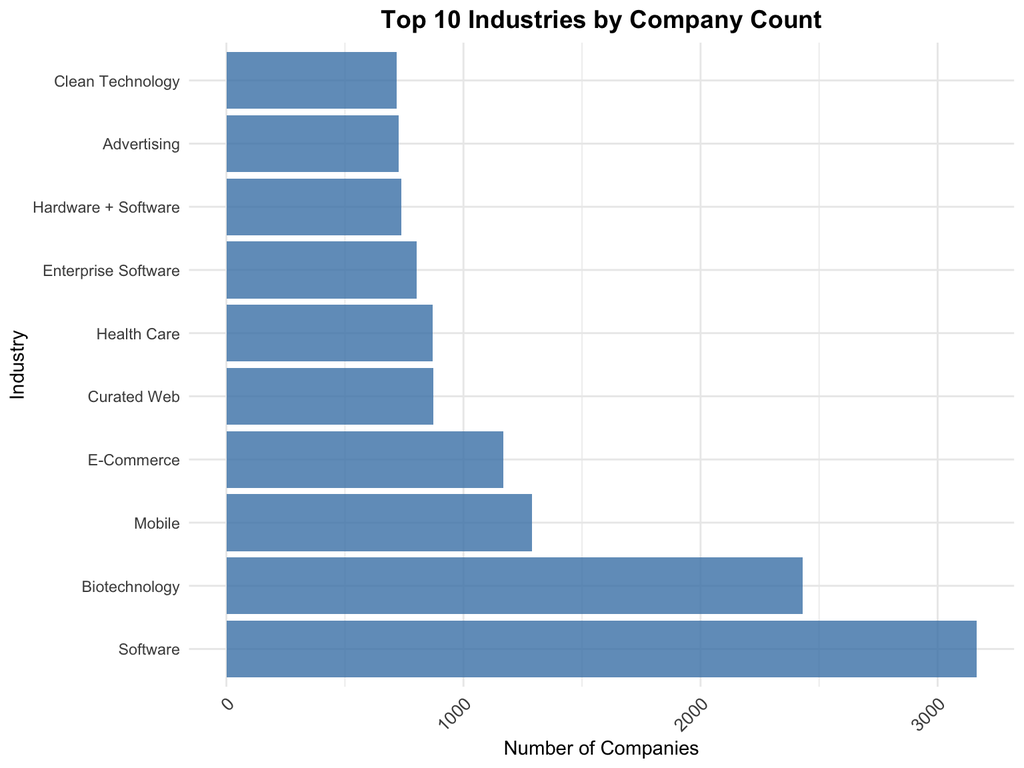

Top 10 Industries by Company Count

```r
# Identify top industries
top_industries <- companies_master %>%
  filter(!is.na(industry)) %>%
  count(industry, sort = TRUE) %>%
  head(10) %>%
  pull(industry)

# Filter data for plotting
companies_plot <- companies_master %>%
  filter(industry %in% top_industries)

# Industry distribution plot
p_industry <- ggplot(companies_plot,
                    aes(x = reorder(industry, industry, function(x) -length(x)))) +
  geom_bar(fill = "steelblue", alpha = 0.8) +
  labs(title = "Top 10 Industries by Company Count",
       x = "Industry",
       y = "Number of Companies") +
  theme(axis.text.x = element_text(angle = 45, hjust = 1, size = 10)) +
  coord_flip()

print(p_industry)
```

## Funding Distribution Analysis

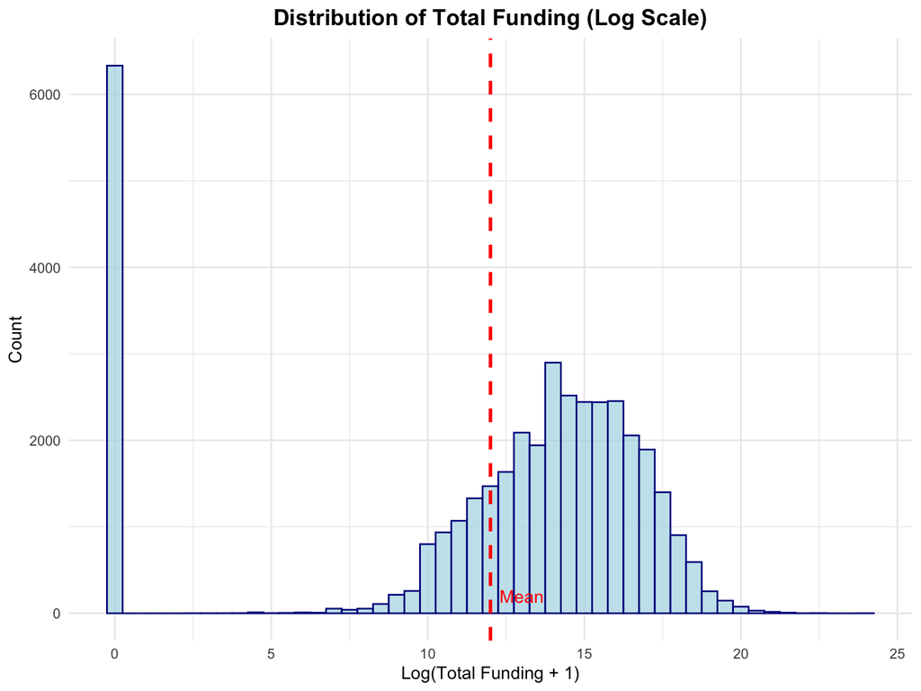

Distribution of Company Funding

```r
p1 <- ggplot(companies_master, aes(x = log_total_funding)) +
  geom_histogram(binwidth = 0.5, fill = "lightblue", color = "darkblue", alpha = 0.7) +
  labs(title = "Distribution of Total Funding (Log Scale)",
       x = "Log(Total Funding + 1)", y = "Count") +
  geom_vline(aes(xintercept = mean(log_total_funding, na.rm = TRUE)),
             color = "red", linetype = "dashed", linewidth = 1) + # FIXED: size to linewidth
  annotate("text", x = mean(companies_master$log_total_funding, na.rm = TRUE) + 1,
           y = 200, label = "Mean", color = "red")

print(p1)
```

## Company Age Analysis

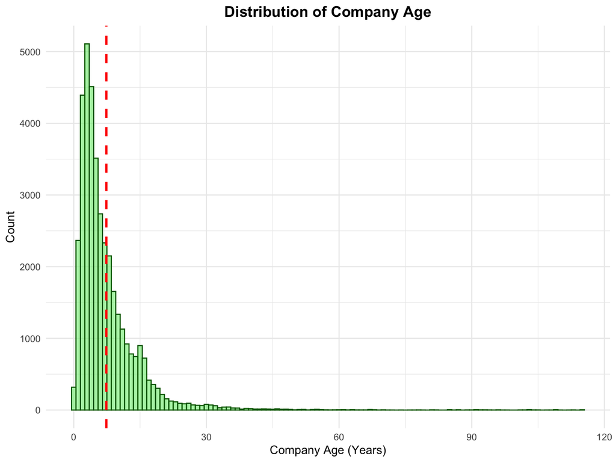

Distribution of Company Age at Cutoff Date

```r
p2 <- ggplot(companies_master, aes(x = company_age)) +
  geom_histogram(binwidth = 1, fill = "lightgreen", color = "darkgreen", alpha = 0.7) +
  labs(title = "Distribution of Company Age",
       x = "Company Age (Years)", y = "Count") +
  geom_vline(aes(xintercept = mean(company_age, na.rm = TRUE)),
             color = "red", linetype = "dashed", linewidth = 1) # FIXED: size to linewidth

print(p2)
```

## Bivariate Analysis

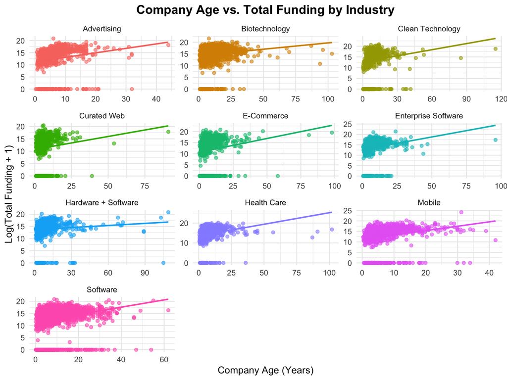

Relationship Between Company Age and Funding by Industry

```r
p3 <- ggplot(companies_plot, aes(x = company_age, y = log_total_funding, color = industry)) +
  geom_point(alpha = 0.6, size = 1.5) +
  geom_smooth(method = "lm", se = FALSE, linewidth = 0.8) + # FIXED: size to linewidth
  labs(title = "Company Age vs. Total Funding by Industry",
       x = "Company Age (Years)",
       y = "Log(Total Funding + 1)",
       color = "Industry") +
  theme(legend.position = "none") +
  facet_wrap(~industry, scales = "free", ncol = 3)

print(p3)
```

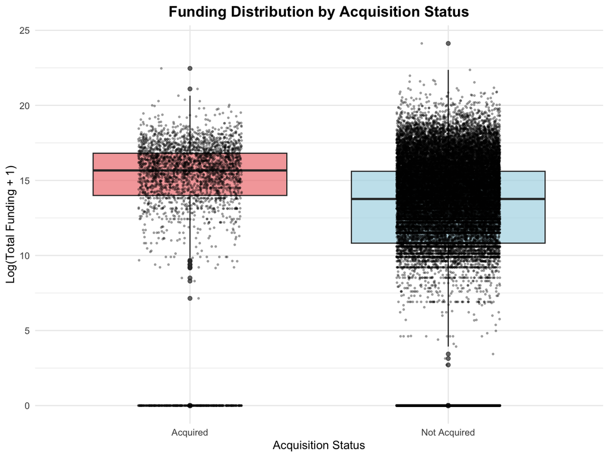

Funding Distribution by Acquisition Status

```r
p4 <- companies_master %>%
  mutate(status = if_else(acquired, "Acquired", "Not Acquired")) %>%
  ggplot(aes(x = status, y = log_total_funding, fill = status)) +
  geom_boxplot(alpha = 0.7) +
  geom_jitter(width = 0.2, alpha = 0.3, size = 0.5) +
  labs(title = "Funding Distribution by Acquisition Status",
       x = "Acquisition Status",
       y = "Log(Total Funding + 1)") +
  scale_fill_manual(values = c("lightcoral", "lightblue")) +
  theme(legend.position = "none")

print(p4)
```

# Statistical Analysis

## Hypothesis Test: Funding Differences by Acquisition Status

**Research Question:** Is there a significant difference in total funding between startups that were acquired and those that were not?

```r
# Separate funding data by acquisition status
acquired_funding <- companies_master$log_total_funding[companies_master$acquired == TRUE]
not_acquired_funding <- companies_master$log_total_funding[companies_master$acquired == FALSE]

# Descriptive statistics
acq_desc <- describe(acquired_funding)
not_acq_desc <- describe(not_acquired_funding)

comparison_stats <- data.frame(
  Group = c("Acquired", "Not Acquired"),
  N = c(length(acquired_funding), length(not_acquired_funding)),
  Mean = c(acq_desc$mean, not_acq_desc$mean),
  SD = c(acq_desc$sd, not_acq_desc$sd),
  Median = c(acq_desc$median, not_acq_desc$median),
  Min = c(acq_desc$min, not_acq_desc$min),
  Max = c(acq_desc$max, not_acq_desc$max)
)

kable(comparison_stats, digits = 3,
      caption = "Descriptive Statistics: Log-Transformed Funding by Acquisition Status") %>%
  kable_styling(bootstrap_options = "striped")
```

Descriptive Statistics: Log-Transformed Funding by Acquisition Status

| Group | N | Mean | SD | Median | Min | Max |
| --- | --- | --- | --- | --- | --- | --- |
| Acquired | 3071 | 13.797 | 5.463 | 15.666 | 0 | 22.464 |
| Not Acquired | 35415 | 11.845 | 5.746 | 13.764 | 0 | 24.127 |

### Assumption Testing

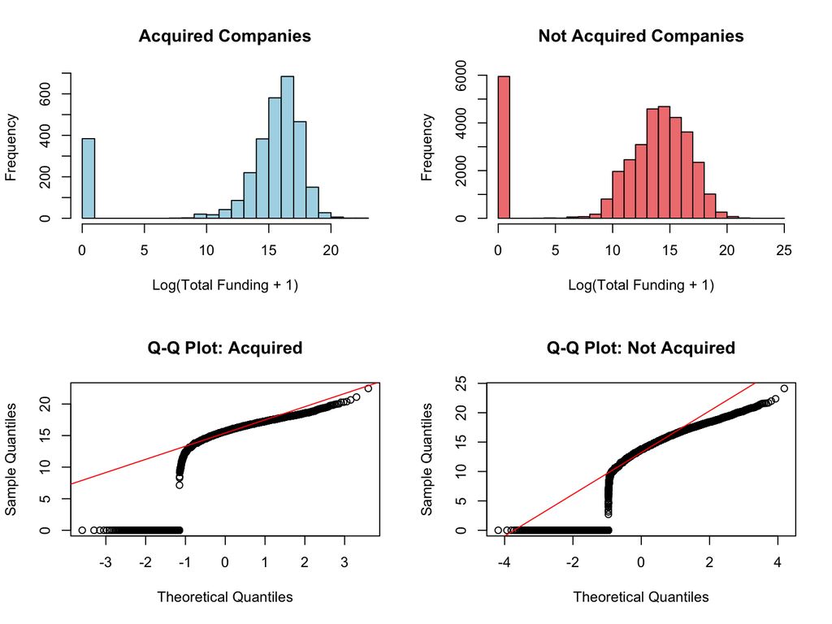

Distribution Comparison and Q-Q Plots

```r
# Create comparison plots
par(mfrow = c(2, 2))

# Histograms
hist(acquired_funding, main = "Acquired Companies",
     xlab = "Log(Total Funding + 1)", col = "lightblue", breaks = 20)
hist(not_acquired_funding, main = "Not Acquired Companies",
     xlab = "Log(Total Funding + 1)", col = "lightcoral", breaks = 20)

# Q-Q plots
qqnorm(acquired_funding, main = "Q-Q Plot: Acquired")
qqline(acquired_funding, col = "red")
qqnorm(not_acquired_funding, main = "Q-Q Plot: Not Acquired")
qqline(not_acquired_funding, col = "red")
```

```r
par(mfrow = c(1, 1))
```

```r
# Test for homogeneity of variance
levene_test <- leveneTest(log_total_funding ~ acquired, data = companies_master)
var_test <- var.test(acquired_funding, not_acquired_funding, alternative = "two.sided")

cat("Levene's Test for Homogeneity of Variance:\n")
```

```
## Levene's Test for Homogeneity of Variance:
```

```r
cat("F =", round(levene_test$`F value`[1], 4), ", p =", round(levene_test$`Pr(>F)`[1], 4), "\n\n")
```

```
## F = 88.0216 , p = 0
```

```r
cat("F-Test for Equal Variances:\n")
```

```
## F-Test for Equal Variances:
```

```r
cat("F =", round(var_test$statistic, 4), ", p =", round(var_test$p.value, 4), "\n")
```

```
## F = 0.904 , p = 2e-04
```

### Statistical Test

```r
# Given non-normal distributions
wilcox_result <- wilcox.test(acquired_funding, not_acquired_funding,
                            paired = FALSE, alternative = "two.sided")

cat("W =", wilcox_result$statistic, "\n")
```

```
## W = 72477644
```

```r
cat("p-value =", format(wilcox_result$p.value, scientific = TRUE, digits = 4), "\n")
```

```
## p-value = 3.973e-207
```

# Mediation Analysis

**Research Question:** Does total funding mediate the relationship between industry type and acquisition likelihood?

```r
# Prepare data for mediation analysis
companies_mediation <- companies_master %>%
  filter(complete.cases(industry, total_funding_usd, acquired)) %>%
  mutate(
    # Create binary industry variable (top industry vs others)
    industry_counts = ave(rep(1, nrow(.)), industry, FUN = sum),
    top_industry_name = names(sort(table(industry), decreasing = TRUE))[1]
  )

top_industry <- companies_mediation$top_industry_name[1]
companies_mediation <- companies_mediation %>%
  mutate(top_industry = ifelse(industry == top_industry, 1, 0))

cat("Mediation Analysis Setup:\n")
```

```
## Mediation Analysis Setup:
```

```r
cat("Sample size:", nrow(companies_mediation), "\n")
```

```
## Sample size: 36509
```

```r
cat("Top industry:", top_industry, "\n")
```

```
## Top industry: Software
```

```r
cat("Companies in top industry:", sum(companies_mediation$top_industry), "\n")
```

```
## Companies in top industry: 3165
```

```r
cat("Acquisition rate (top industry):",
    round(mean(companies_mediation$acquired[companies_mediation$top_industry == 1]) * 100, 1), "%\n")
```

```
## Acquisition rate (top industry): 11.2 %
```

```r
cat("Acquisition rate (other industries):",
    round(mean(companies_mediation$acquired[companies_mediation$top_industry == 0]) * 100, 1), "%\n")
```

```
## Acquisition rate (other industries): 7.9 %
```

```r
set.seed(123)

# Step 1: Industry → Funding (a path)
model_a <- lm(log_total_funding ~ top_industry, data = companies_mediation)

# Step 2: Industry + Funding → Acquisition (b and c' paths)
model_b <- glm(acquired ~ top_industry + log_total_funding,
               data = companies_mediation, family = binomial)

# Bootstrap mediation analysis
mediation_results <- mediate(model_a, model_b,
                           treat = "top_industry",
                           mediator = "log_total_funding",
                           boot = TRUE, sims = 1000)

# Display results
summary(mediation_results)
```

```
##
## Causal Mediation Analysis
##
## Nonparametric Bootstrap Confidence Intervals with the Percentile Method
##
##                           Estimate 95% CI Lower 95% CI Upper   p-value
## ACME (control)           0.0051949    0.0038559    0.0067566 < 2.2e-16 ***
## ACME (treated)           0.0067923    0.0049760    0.0087451 < 2.2e-16 ***
## ADE (control)            0.0283821    0.0175762    0.0392406 < 2.2e-16 ***
## ADE (treated)            0.0299795    0.0185886    0.0413585 < 2.2e-16 ***
## Total Effect             0.0351744    0.0237954    0.0468658 < 2.2e-16 ***
## Prop. Mediated (control) 0.1476895    0.1024705    0.2290129 < 2.2e-16 ***
## Prop. Mediated (treated) 0.1931037    0.1426571    0.2727172 < 2.2e-16 ***
## ACME (average)           0.0059936    0.0044221    0.0077264 < 2.2e-16 ***
## ADE (average)            0.0291808    0.0180685    0.0403167 < 2.2e-16 ***
## Prop. Mediated (average) 0.1703966    0.1232264    0.2511233 < 2.2e-16 ***
## ---
## Signif. codes:  0 '***' 0.001 '**' 0.01 '*' 0.05 '.' 0.1 ' ' 1
##
## Sample Size Used: 36509
##
##
## Simulations: 1000
```

```r
# Extract key results for interpretation
med_summary <- summary(mediation_results)
acme <- med_summary$d.avg
acme_p <- med_summary$d.avg.p
ade <- med_summary$z.avg
ade_p <- med_summary$z.avg.p
total_effect <- med_summary$tau.coef
prop_mediated <- med_summary$n.avg

# Determine mediation type
if(acme_p < 0.05 & ade_p >= 0.05) {
  mediation_type <- "fully mediated"
} else if(acme_p < 0.05 & ade_p < 0.05) {
  mediation_type <- "partially mediated"
} else {
  mediation_type <- "no significant mediation"
}

cat("Mediation Analysis Summary:\n")
```

```
## Mediation Analysis Summary:
```

```r
cat("Indirect effect (ACME):", round(acme, 4), "p =", round(acme_p, 4), "\n")
```

```
## Indirect effect (ACME): 0.006 p = 0
```

```r
cat("Direct effect (ADE):", round(ade, 4), "p =", round(ade_p, 4), "\n")
```

```
## Direct effect (ADE): 0.0292 p = 0
```

```r
cat("Total effect:", round(total_effect, 4), "\n")
```

```
## Total effect: 0.0352
```

```r
cat("Proportion mediated:", round(prop_mediated, 4), "\n")
```

```
## Proportion mediated: 0.1704
```

```r
cat("Mediation type:", mediation_type, "\n")
```

```
## Mediation type: partially mediated
```

**Interpretation:** The mediation analysis indicates partially mediated relationship, with funding serving as a significant mediator between industry type and acquisition likelihood.

# Chi-Square Test

**Research Question:** Is there a relationship between industry sector and acquisition status?

## Contingency Table

```r
# Create contingency table
contingency_table <- table(companies_master$industry_grouped, companies_master$acquired)
colnames(contingency_table) <- c("Not Acquired", "Acquired")

# Display the table
kable(contingency_table,
      caption = "Contingency Table: Industry Sector by Acquisition Status") %>%
  kable_styling(bootstrap_options = "striped")
```

Contingency Table: Industry Sector by Acquisition Status

|  | Not Acquired | Acquired |
| --- | --- | --- |
| Entertainment | 1067 | 83 |
| Finance | 760 | 69 |
| Health | 3237 | 158 |
| Marketing | 706 | 100 |
| Mobile | 1271 | 135 |
| Other | 28374 | 2526 |

```r
# Calculate percentages
prop_table <- prop.table(contingency_table, margin = 1) * 100
kable(round(prop_table, 1),
      caption = "Acquisition Rates by Industry Sector (%)") %>%
  kable_styling(bootstrap_options = "striped")
```

Acquisition Rates by Industry Sector (%)

|  | Not Acquired | Acquired |
| --- | --- | --- |
| Entertainment | 92.8 | 7.2 |
| Finance | 91.7 | 8.3 |
| Health | 95.3 | 4.7 |
| Marketing | 87.6 | 12.4 |
| Mobile | 90.4 | 9.6 |
| Other | 91.8 | 8.2 |